# R_CIA3_SP

R Akhilandeshwari

4/22/2021

```r
setwd('C:/Desktop/R/CIA3')
getwd()
```

```
## [1] "C:/Desktop/R/CIA3"
```

# TITLE : IMPACT OF DIFFERENT FACTORS ON STUDENT’S ACADEMICS

## DOMAIN : EDUCATION

## METHOD : RANDOM FOREST, XGBOOST

## TECHNIQUE : REGRESSION

### PROJECT DESCRIPTION :-

**Today’s students are tomorrow’s citizens. But it is pathetic situation for all the individual because, though there are many resources available for students, they are unable to score equally good. There are many factors that is influencing the student’s academic performance. As we all know that, in present corporate world, the entry ticket for a job is the student’s academic score i.e., first clearance round. Based on the student’s academic score they are proceeded to further rounds. As we all know that the unemployment rate is also more. So, in order to decrease the unemployment rate and increase the economy we have to build strong grounds for the students, whereby they will simultaneously increase their academic score and overall growth of an individual is met.**

### DATASET :-

**The dataset consists of 480 student records and 17 features. The features are classified into three major categories:** **(1) Demographic features such as gender and nationality.** **(2) Academic background features such as educational stage, grade Level and section.** **(3) Behavioral features such as raised hand on class, opening resources, answering survey by parents, and school satisfaction.**

*This is an educational data set which is collected from learning management system (LMS) called Kalboard 360. Kalboard 360 is a multi-agent LMS, which has been designed to facilitate learning through the use of leading-edge technology. The dataset has nominal and numerical data. Source:Kaggle*

### Importing the data and analysing it

```r
sp <- read.csv('EDU_DATA.csv')
print(ncol(sp))
```

```
## [1] 17
```

```r
print(nrow(sp))
```

```
## [1] 480
```

**We have 17 attributes with 480 records**

```r
str(sp)
```

```
## 'data.frame':    480 obs. of  17 variables:
##  $ gender                  : chr  "M" "M" "M" "M" ...
##  $ NationalITy             : chr  "KW" "KW" "KW" "KW" ...
##  $ PlaceofBirth            : chr  "KuwaIT" "KuwaIT" "KuwaIT" "KuwaIT" ...
##  $ StageID                 : chr  "lowerlevel" "lowerlevel" "lowerlevel" "lowerlevel" ...
##  $ GradeID                 : chr  "G-04" "G-04" "G-04" "G-04" ...
##  $ SectionID               : chr  "A" "A" "A" "A" ...
##  $ Topic                   : chr  "IT" "IT" "IT" "IT" ...
##  $ Semester                : chr  "F" "F" "F" "F" ...
##  $ Relation                : chr  "Father" "Father" "Father" "Father" ...
##  $ raisedhands             : int  15 20 10 30 40 42 35 50 12 70 ...
##  $ VisITedResources        : int  16 20 7 25 50 30 12 10 21 80 ...
##  $ AnnouncementsView       : int  2 3 0 5 12 13 0 15 16 25 ...
##  $ Discussion              : int  20 25 30 35 50 70 17 22 50 70 ...
##  $ ParentAnsweringSurvey   : chr  "Yes" "Yes" "No" "No" ...
##  $ ParentschoolSatisfaction: chr  "Good" "Good" "Bad" "Bad" ...
##  $ StudentAbsenceDays      : chr  "Under-7" "Under-7" "Above-7" "Above-7" ...
##  $ Class                   : chr  "M" "M" "L" "L" ...
```

**Except raisedhands, VisITedResources, AnnouncementsView, Discussion rest all attributes are categorical.**

## EXPLORATORY DATA ANALYSIS

### 1. Checking the missing values in the data

```r
colSums(is.na(sp))
```

```
##                   gender              NationalITy             PlaceofBirth
##                        0                        0                        0
##                  StageID                  GradeID                SectionID
##                        0                        0                        0
##                    Topic                 Semester                 Relation
##                        0                        0                        0
##              raisedhands         VisITedResources        AnnouncementsView
##                       12                        8                        6
##               Discussion    ParentAnsweringSurvey ParentschoolSatisfaction
##                        0                        0                        0
##       StudentAbsenceDays                    Class
##                        0                        0
```

```r
library(VIM)
```

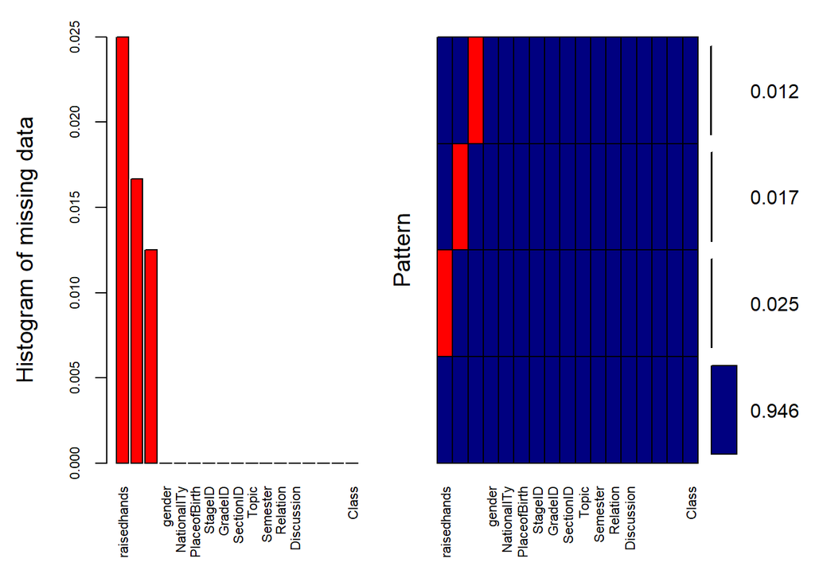

```
##
##  Variables sorted by number of missings:
##                  Variable      Count
##               raisedhands 0.02500000
##          VisITedResources 0.01666667
##         AnnouncementsView 0.01250000
##                    gender 0.00000000
##               NationalITy 0.00000000
##              PlaceofBirth 0.00000000
##                   StageID 0.00000000
##                   GradeID 0.00000000
##                 SectionID 0.00000000
##                     Topic 0.00000000
##                  Semester 0.00000000
##                  Relation 0.00000000
##                Discussion 0.00000000
##     ParentAnsweringSurvey 0.00000000
##  ParentschoolSatisfaction 0.00000000
##        StudentAbsenceDays 0.00000000
##                     Class 0.00000000
```

```r
aggr_plot <- aggr(sp, col=c('navyblue','red'), numbers=TRUE, sortVars=TRUE, labels=names(data), cex.axis=.7, gap=3, ylab=c("Histogram of missing data","Pattern"))
```

**There are 3 different columns with null values in it.**

### 2. Imputing the Missing values with mean

```r
# impute with the mean
sp$raisedhands[is.na(sp$raisedhands)] <- mean(sp$raisedhands,na.rm=TRUE)

sp$VisITedResources[is.na(sp$VisITedResources)] <- mean(sp$VisITedResources,na.rm=TRUE)

sp$AnnouncementsView[is.na(sp$AnnouncementsView)] <- mean(sp$AnnouncementsView,na.rm=TRUE)
```

### 3. Checking the number of unique values for each categorical column in the data i.e.,levels of each categorical column in the data

```r
apply(sp,2, function(x) length(unique(x)))
```

```
##                   gender              NationalITy             PlaceofBirth
##                        2                       14                       14
##                  StageID                  GradeID                SectionID
##                        3                       10                        3
##                    Topic                 Semester                 Relation
##                       12                        2                        2
##              raisedhands         VisITedResources        AnnouncementsView
##                       83                       90                       89
##               Discussion    ParentAnsweringSurvey ParentschoolSatisfaction
##                       90                        2                        2
##       StudentAbsenceDays                    Class
##                        2                        3
```

**There are columns with 2,3,14 unique values**

### 4. Correlation plot

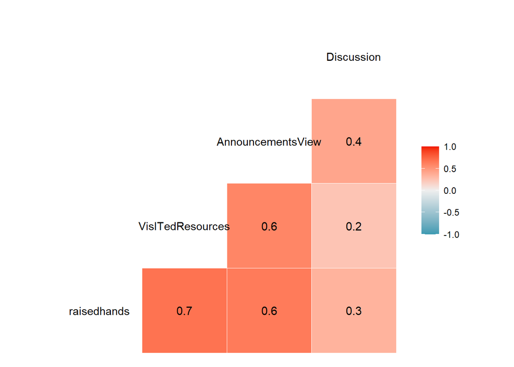

```r
library(GGally)
ggcorr(sp,label=T)
```

### 5. Analysing both numerical and categorical variables at one time

```r
library(Hmisc)
describe(sp)
```

```
## sp
##
##  17  Variables      480  Observations
## --------------------------------------------------------------------------------
## gender
##        n  missing distinct
##      480        0        2
##
## Value          F     M
## Frequency    175   305
## Proportion 0.365 0.635
## --------------------------------------------------------------------------------
## NationalITy
##        n  missing distinct
##      480        0       14
##
## lowest : Egypt       Iran        Iraq        Jordan      KW
## highest: SaudiArabia Syria       Tunis       USA         venzuela
##
## Egypt (9, 0.019), Iran (6, 0.013), Iraq (22, 0.046), Jordan (172, 0.358), KW
## (179, 0.373), lebanon (17, 0.035), Lybia (6, 0.013), Morocco (4, 0.008),
## Palestine (28, 0.058), SaudiArabia (11, 0.023), Syria (7, 0.015), Tunis (12,
## 0.025), USA (6, 0.013), venzuela (1, 0.002)
## --------------------------------------------------------------------------------
## PlaceofBirth
##        n  missing distinct
##      480        0       14
##
## lowest : Egypt       Iran        Iraq        Jordan      KuwaIT
## highest: SaudiArabia Syria       Tunis       USA         venzuela
##
## Egypt (9, 0.019), Iran (6, 0.013), Iraq (22, 0.046), Jordan (176, 0.367),
## KuwaIT (180, 0.375), lebanon (19, 0.040), Lybia (6, 0.013), Morocco (4, 0.008),
## Palestine (10, 0.021), SaudiArabia (16, 0.033), Syria (6, 0.013), Tunis (9,
## 0.019), USA (16, 0.033), venzuela (1, 0.002)
## --------------------------------------------------------------------------------
## StageID
##        n  missing distinct
##      480        0        3
##
```

[output cut: 102 more lines]

```
##        n  missing distinct
##      480        0        2
##
## Value      Above-7 Under-7
## Frequency      191     289
## Proportion   0.398   0.602
## --------------------------------------------------------------------------------
## Class
##        n  missing distinct
##      480        0        3
##
## Value          H     L     M
## Frequency    142   127   211
## Proportion 0.296 0.265 0.440
## --------------------------------------------------------------------------------
```

### 6. Checking the distribution of the data

```r
library(funModeling)
```

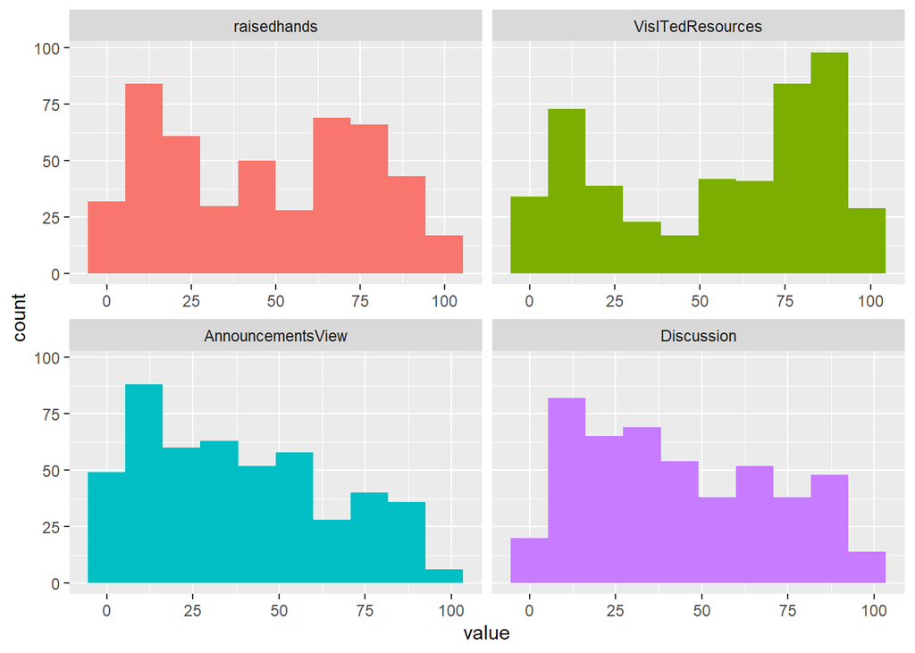

```r
plot_num(sp)
```

## BUILDING THE MODEL

```r
#Installing the packages
#install.packages('data.table')
#install.packages('mlr')
#install.packages('h2o')

#load libraries
library('data.table')
library('mlr')
library('h2o')
```

### Splitting the model

```r
set.seed(480)
spts=sample(1:nrow(sp),0.7*nrow(sp))#70% Training Data
train<-sp[spts,]
test<-sp[-spts,]
```

### Encoding the categorical variables

```r
#install.packages("superml")
library(superml)
cat_cols <- names(train)[sapply(train, is.character)]

for(c in cat_cols){
    lbl <- LabelEncoder$new()
    lbl$fit(c(train[[c]], test[[c]]))
    train[[c]] <- lbl$transform(train[[c]])
    test[[c]] <- lbl$transform(test[[c]])
}
```

```r
library(randomForest)
#fit the random forest model
model <- randomForest(formula = Class ~ .,data = train)
model
```

```
##
## Call:
##  randomForest(formula = Class ~ ., data = train)
##                Type of random forest: regression
##                      Number of trees: 500
## No. of variables tried at each split: 5
##
##           Mean of squared residuals: 0.3975735
##                     % Var explained: 39.82
```

**The Mean Squared error of the model is less, but it cannot be negligible. So, we have the scope of improvement.**

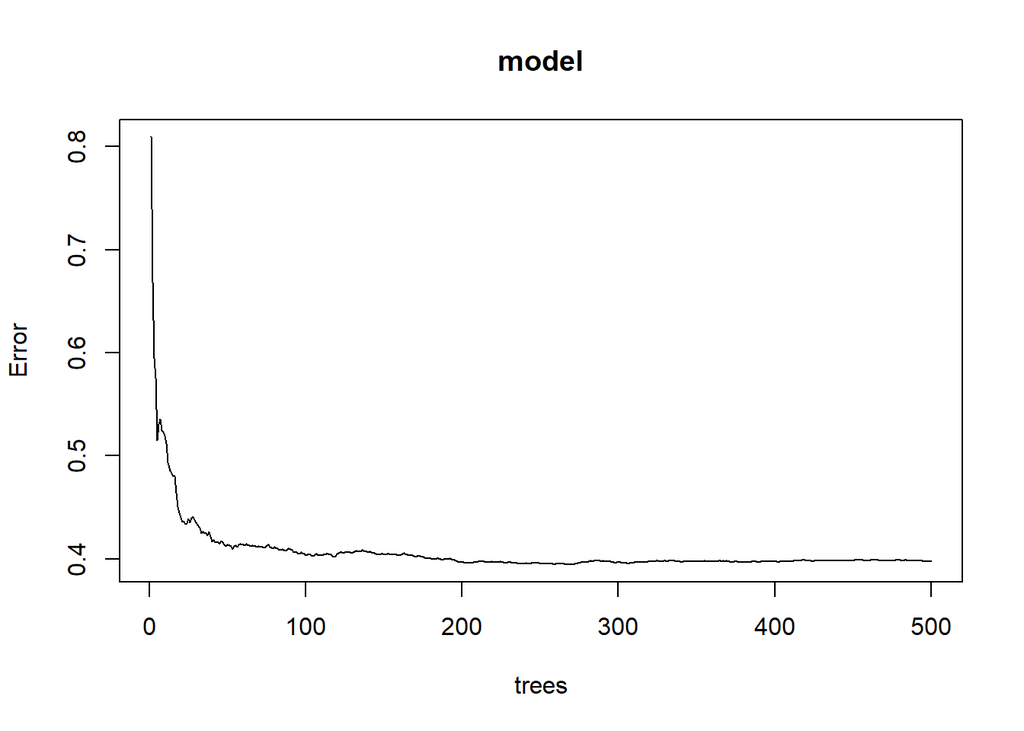

```r
#plot the test MSE by number of trees
plot(model)
```

**The error is decreased as the number of trees increases.**